# 키로 몸무게를 예측한다.

### 선형 회귀분석(Linear Regression)

- 스칼라 종속변수 y와 하나 이상의 독립변수 간의 관계를 모델링하는 선형 접근법
- 예) 키와 몸무게, 신발 사이즈와 키

```python
from IPython.display import Image
Image(url= "https://i0.wp.com/hleecaster.com/wp-content/uploads/2019/12/linear01.jpg")
```

[figure not shown]

```python
# 주피터 노트북 환경설정
import warnings
warnings.filterwarnings('ignore')
warnings.simplefilter('ignore')

from IPython.display import set_matplotlib_formats
set_matplotlib_formats("retina")

from IPython.display import Image

from IPython.core.display import display, HTML
display(HTML("<style>.container { font-weight: bold !important; }</style>"))
display(HTML("<style>.container { width: 98% !important; }</style>"))
```

```python
import numpy as np
import pandas as pd
import matplotlib
import matplotlib.pyplot as plt
import seaborn as sns
%matplotlib inline
plt.rcParams['font.size'] = 12.0
plt.rcParams['font.family'] = 'Malgun Gothic'
matplotlib.rcParams['axes.unicode_minus'] = False
```

# 머신러닝 과정

- 모듈 임포트
- 데이타 수집 (학습데이타)
- 데이타 전처리
- 데이터 학습 (모델화)
- 데이터 예측 (테스트데이타)
- 데이터 테스트 (정답률)

## 데이타 수집

https://www.kaggle.com/mustafaali96/weight-height input/weight-height.csv

```python
df = pd.read_csv("input/weight-height.csv")
df.head()
```

|  | Gender | Height | Weight |
| --- | --- | --- | --- |
| 0 | Male | 73.847017 | 241.893563 |
| 1 | Male | 68.781904 | 162.310473 |
| 2 | Male | 74.110105 | 212.740856 |
| 3 | Male | 71.730978 | 220.042470 |
| 4 | Male | 69.881796 | 206.349801 |

```python
df.shape
```

```
(10000, 3)
```

```python
df.dtypes
```

```
Gender     object
Height    float64
Weight    float64
dtype: object
```

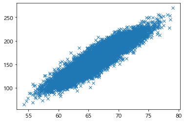

```python
plt.plot(df['Height'],df['Weight'], 'x')
```

# 데이타 전처리 (Feature engineering)

- 학습데이타는 2차원이어야한다.

```python
train_x = df['Height'].values.reshape(-1,1)
train_y = df['Weight']
```

```python
# 단위를 변경하고 싶다면?
# Inch => cm (1 Inch는 2.54 cm)
# 1 lb => kg 0.453592 kg
```

```python
train_x = train_x*2.54
```

```python
train_x
```

```
array([[187.57142322],
       [174.70603628],
       [188.2396677 ],
       ...,
       [162.22470022],
       [175.34697755],
       [157.33838453]])
```

```python
train_x.ndim
```

```
2
```

```python
train_y = train_y*0.453592
train_y
```

```
0       109.720985
1        73.622732
2        96.497550
3        99.809504
4        93.598619
           ...
9995     62.041159
9996     77.504315
9997     58.275377
9998     74.322166
9999     51.550324
Name: Weight, Length: 10000, dtype: float64
```

### 데이타 학습 : 모델링(RandomFores)

```python
# Regression 모듈 임포트
# from sklearn.linear_model import LinearRegression
# from sklearn.neighbors import KNeighborsRegressor
# from sklearn.tree import DecisionTreeRegressor
from sklearn.ensemble import RandomForestRegressor
```

```python
model = RandomForestRegressor()
# model = LinearRegression()
model.fit(train_x, train_y)
```

```
RandomForestRegressor()
```

### 모델 테스트 : 예측

```python
model.predict([[167]])
```

```
array([66.19410676])
```

### 예측한 데이터의 시각화

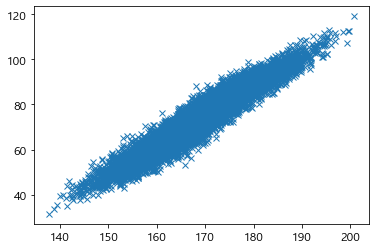

```python
plt.plot(train_x, model.predict(train_x), 'x')
plt.show()
```

## 검증 - Score

- 0에 근접할수록 좋은 데이터

*** Cross Validation 교차 검증

일반화 성능을 측정하기 위해 데이터를 여러 번 반복해서 나누고 여러 모델을 학습한다.image.png이미지 출처 : https://www.researchgate.net/figure/228403467_fig2_Figure-4-k-fold-cross-validation-scheme-example KFold 교차검증 데이터를 폴드라 부르는 비슷한 크기의 부분집합(n_splits)으로 나누고 각각의 폴드 정확도를 측정한다. 첫 번째 폴드를 테스트 세트로 사용하고 나머지 폴드를 훈련세트로 사용하여 학습한다. 나머지 훈련세트로 만들어진 세트의 정확도를 첫 번째 폴드로 평가한다. 다음은 두 번째 폴드가 테스트 세트가 되고 나머지 폴드의 훈련세트를 두 번째 폴드로 정확도를 측정한다. 이 과정을 마지막 폴드까지 반복한다. 이렇게 훈련세트와 테스트세트로 나누는 N개의 분할마다 정확도를 측정하여 평균 값을 낸게 정확도가 된다.

```python
Image(url='https://camo.githubusercontent.com/13e2daa5843eb57377d27934a5da515bb2dd4bd4/68747470733a2f2…')
```

[figure not shown]

*** RMSLE 과대평가 된 항목보다는 과소평가 된 항목에 패널티를 준다. 오차(Error)를 제곱(Square)해서 평균(Mean)한 값의 제곱근(Root) 으로 값이 작을 수록 정밀도가 높다. 0에 가까운 값이 나올 수록 정밀도가 높은 값이다. Submissions are evaluated one the Root Mean Squared Logarithmic Error (RMSLE) $$ \sqrt{\frac{1}{n} \sum_{i=1}^n (\log(p_i + 1) - \log(a_i+1))^2 } $$ ${n}$ is the number of hours in the test set $p_i$ is your predicted count $a_i$ is the actual count $\log(x)$ is the natural logarithm RMSLE cost function 잔차(residual)에 대한 평균에 로그를 씌운 값이다. => 과대평가 된 항목보다 과소 평가 된 항목에 패널티를 주기위해 정답에 대한 오류를 숫자로 나타낸 값으로 값이 클 수록 오차가 크다는 의미다. 값이 작을 수록 오류가 적다는 의미를 나타낸다.

```python
from sklearn.metrics import make_scorer

def rmsle(predicted_values, actual_values):
    # 넘파이로 배열 형태로 바꿔준다.
    predicted_values = np.array(predicted_values)
    actual_values = np.array(actual_values)

    # 예측값과 실제 값에 1을 더하고 로그를 씌워준다.
    log_predict = np.log(predicted_values + 1)
    log_actual = np.log(actual_values + 1)

    # 위에서 계산한 예측값에서 실제값을 빼주고 제곱을 해준다.
    difference = log_predict - log_actual
    # difference = (log_predict - log_actual) ** 2
    difference = np.square(difference)

    # 평균을 낸다.
    mean_difference = difference.mean()

    # 다시 루트를 씌운다.
    score = np.sqrt(mean_difference)

    return score

rmsle_scorer = make_scorer(rmsle)
rmsle_scorer
```

```
make_scorer(rmsle)
```

```python
from sklearn.model_selection import KFold
from sklearn.model_selection import cross_val_score

k_fold = KFold(n_splits=10, shuffle=True, random_state=0)
k_fold
```

```
KFold(n_splits=10, random_state=0, shuffle=True)
```

```python
%time score = cross_val_score(model, train_x, train_y, cv=k_fold, scoring=rmsle_scorer)

score = cross_val_score(model, train_x, train_y, cv=k_fold, scoring=rmsle_scorer)
score = score.mean()

print("Score= {0:.5f}".format(score))
```

```
Wall time: 15 s
Score= 0.09336
```